# Intro to Bayesian Computation

James D. Wilson

April 24, 2017

## Numerical Integration

1. **Stochastic Approximation**

Below, we consider the example of approximating two quantities in the Normal-Normal model specified on slide 8 of Lecture 7:

- $E[log(\theta)]$
- $p(\tilde{y} \mid \mathbf{y})$

**First, generate data**: in practice, we observe this data. But, for this example, we assume that our model is appropriate and that our data does arise from the N($\theta$, 2) distribution.

```r
set.seed(123)
#first, simulate some data

#Draw from prior distribution
prior.thetas <- rnorm(100, mean = 0, sd = 1)

#Draw from data generating process (usually observed in practice). We will draw from the mean of theta given by the distribution of prior.thetas
y <- rnorm(1000, mean = mean(prior.thetas), sd = sqrt(2))
```

**Approximating** $E[log(|\theta|) \mid \mathbf{y}]$

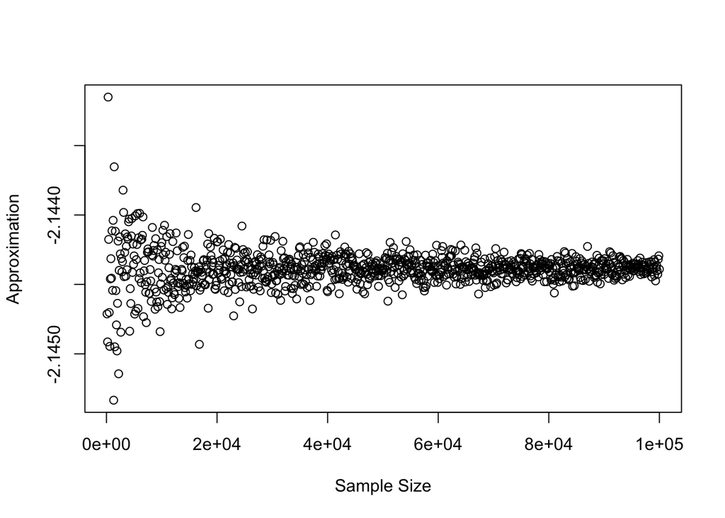

```r
approx.log <- function(S){
  theta.given.y <- rnorm(S, mean = (sum(y)/2)/(1 + 500), sd = 1/(1 + 500))
  result <- (1/S) * sum(log(abs(theta.given.y)))
  return(result)
}

#Try this for S between 100 and 10000
E.log <- rep(0, length(seq(100, 100000, 100)))
i <- 0
for(S in seq(100, 100000, 100)){
  i <- i+1
  E.log[i] <- approx.log(S)
}

#Look at the approximation as the number of samples from the posterior tends to infinity
plot(y = E.log, x = seq(100, 100000, 100), xlab = "Sample Size", ylab = "Approximation")
```

We can see from above that the approximation converges as $S \rightarrow \infty$.

**Approximating** $p(\tilde{y} \mid \mathbf{y})$

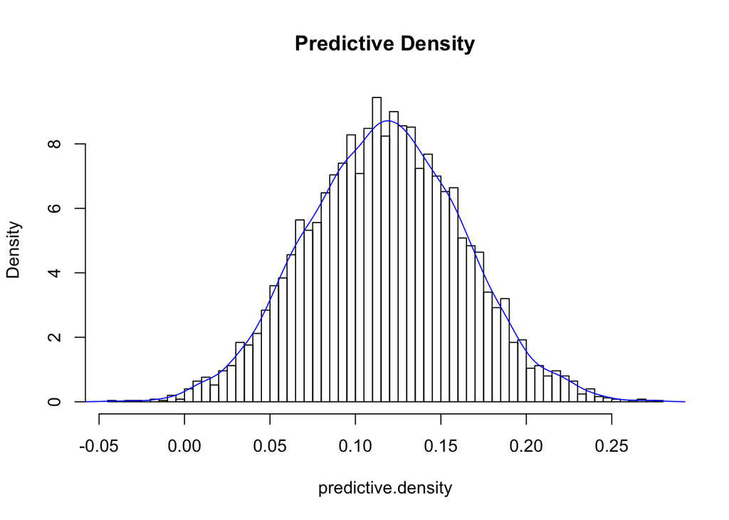

```r
approx.posterior <- function(S, N){
  #S = number of draws from the posterior distribution
  #N = number of draws from the data distribution
  theta.given.y <- rnorm(S, mean = (sum(y)/2)/(1 + 500), sd = 1/(1 + 500))
  density.y.tilde <- matrix(0, nrow = N, ncol = S)
  for(s in 1:S){
    density.y.tilde[, s] <- rnorm(N, mean = theta.given.y[s], sd = sqrt(2))
  }
  result <- (1/S) * rowSums(density.y.tilde)
  return(result)
}

#Sample 1000 times from posterior and get a distribution over 5000 samples

predictive.density <- approx.posterior(S = 1000, N = 5000)


#let's look at the histogram for this

hist(predictive.density, probability = TRUE, n = 50, main = "Predictive Density")
lines(density(predictive.density), col = "blue")
```

## Rejection Sampling Example

First, create our posterior that we want to try to sample from. In this case, we want a Beta(3, 10) density.

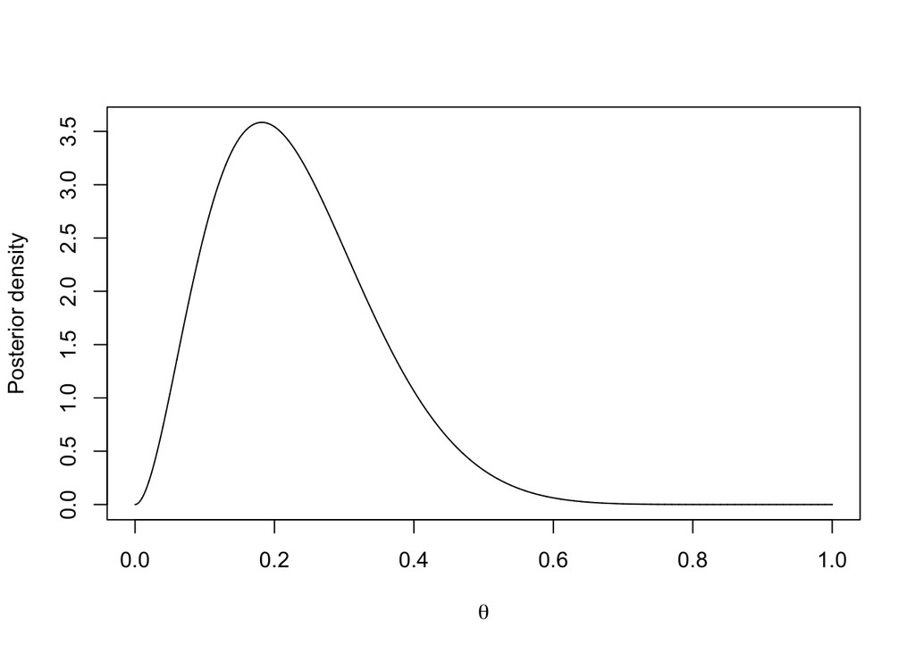

```r
knownDensity <- function(x){return(dbeta(x, 3, 10))}
#show a plot of this
x <- seq(0, 1, 0.0001)
posterior <- knownDensity(x)
plot(y = posterior, x = x, type = "l", ylab = "Posterior density", xlab = expression(theta))
```

Now, we simulate from this using rejection sampling and the scheme we discussed on slide 15.

```r
#Generating n samples from the density
Rejection.Sampling <- function(n, M){
  samples <- rep(0, n)
  for(i in 1:n){
    condition = FALSE
    while(condition == FALSE){
      theta <- runif(1, min = 0, max = 1)
      post.value <- knownDensity(theta)
      g.value <- dunif(theta, min = 0, max = 1)
      test <- post.value / (M*g.value)
      U <- runif(1, min = 0, max = 1)
      if(U < test){
        condition = TRUE
        samples[i] <- theta
        }
    }
  }
  return(samples)
}
```

Generate 1000 samples using rejection sampling

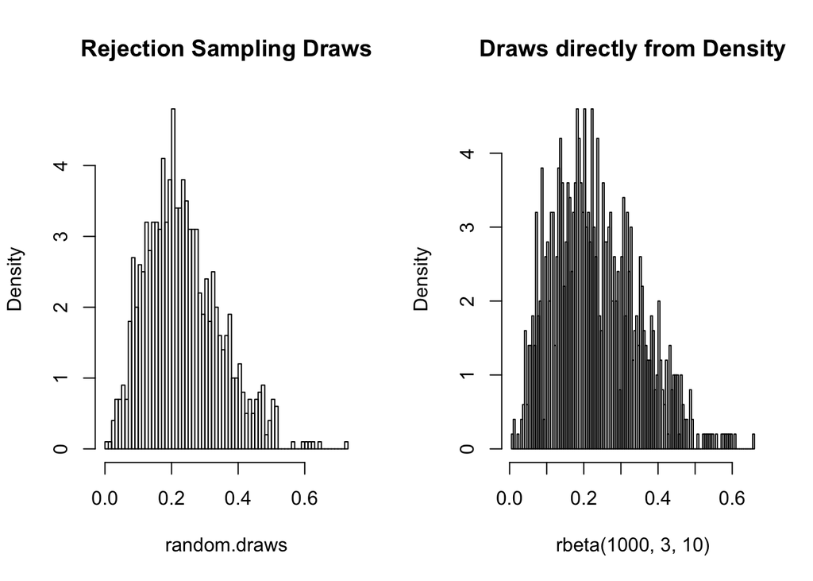

```r
M <- 4 #our best guess as to the maximum value of the posterior density
random.draws <- Rejection.Sampling(1000, M)

#Compare the two
par(mfrow = c(1, 2))
hist(random.draws, n = 100, probability = TRUE, main = "Rejection Sampling Draws")

hist(rbeta(1000, 3, 10), n = 100, probability = TRUE, main = "Draws directly from Density")
```

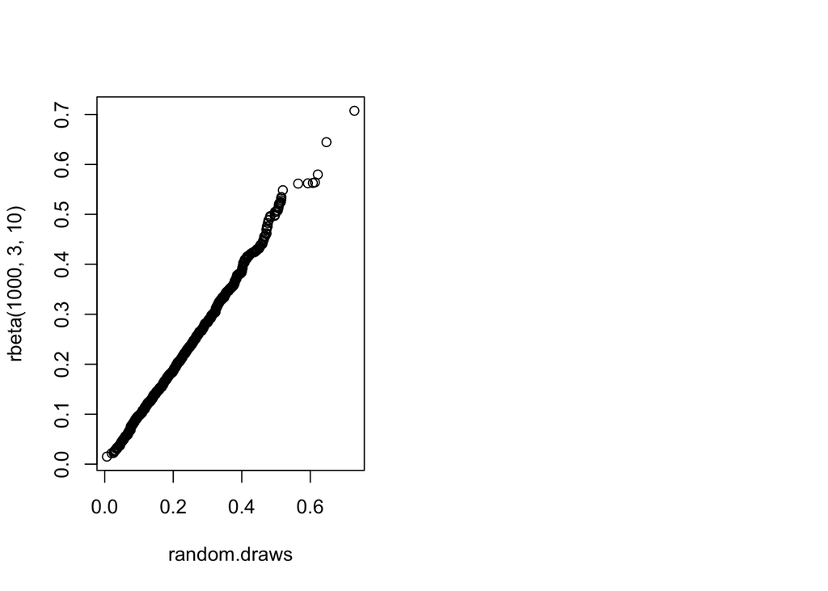

```r
qqplot(random.draws, rbeta(1000, 3, 10))
```

## Importance Sampling Example

```r
#The unnormalized density function for the true posterior
unnormalized.q.theta <- function(theta){
  result <- exp(-(theta)^2 / 2)
  return(result)
}

#Our proposal distribution
g.theta <- function(theta){
  result <- dt(theta, df = 3)
  return(result)
}

#Importance Weights
imp.weights <- function(theta){
  result <- unnormalized.q.theta(theta) / g.theta(theta)
  return(result)
}

##Estimation of the Expectation
S <- 1000 #1000 samples
#draw samples from t(3, sqrt(4/3)) distribution
thetas <- rt(S, df = 3)
expectation <- sum(thetas*imp.weights(thetas)) / sum(imp.weights(thetas))

expectation
```

```
## [1] -0.05618537
```

```r
variance <- sum(thetas^2*imp.weights(thetas))/sum(imp.weights(thetas)) - expectation^2

variance
```

```
## [1] 0.9727306
```

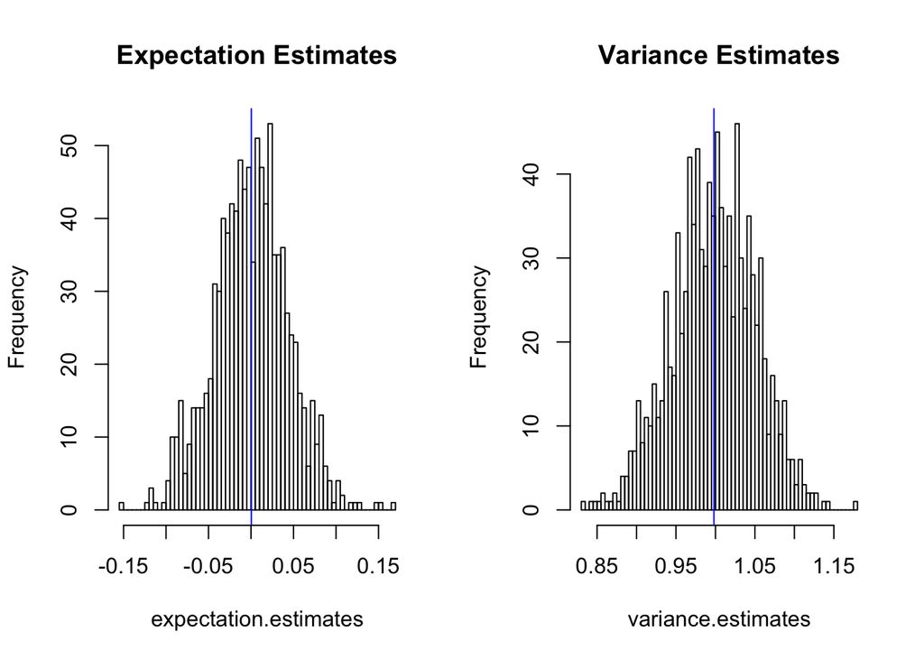

```r
#Replicate these approximations 1000 times and get a distribution

expectation.function <- function(N, S){
  #get N estimates using S importance samples
  expectation <- rep(0, N)
  for(i in 1:N){
  thetas <- rt(S, df = 3)
  expectation[i] <- sum(thetas*imp.weights(thetas)) /
                    sum(imp.weights(thetas))
  }
  return(expectation)
}

variance.function <- function(N, S){
  variance <- rep(0, N)
  for(i in 1:N){
    thetas <- rt(S, df = 3)
    variance[i] <- sum(thetas^2*imp.weights(thetas)) /
                   sum(imp.weights(thetas)) -
                   (sum(thetas*imp.weights(thetas)) /
                   sum(imp.weights(thetas)))^2
  }
  return(variance)
}

expectation.estimates <- expectation.function(N = 1000, S = 500)
variance.estimates <- variance.function(N = 1000, S = 500)

#Plot these side by side
par(mfrow = c(1,2))
hist(expectation.estimates, n = 100, main = "Expectation Estimates")
abline(v = mean(expectation.estimates), col = "blue")
hist(variance.estimates, n = 100, main = "Variance Estimates")
abline(v = mean(variance.estimates), col = "blue")
```